# R Notebook

```r
library(tidyverse)
library(ggplot2)
library(ggwordcloud)
```

```r
#Read in the data
students_companies <- read_csv("../outputs/student_companies.csv")
```

```r
summary(students_companies)
```

```
  student_ID        partner_status        gender               age
 Length:653         Length:653         Length:653         Min.   : 0.00
 Class :character   Class :character   Class :character   1st Qu.:27.00
 Mode  :character   Mode  :character   Mode  :character   Median :31.00
                                                          Mean   :30.22
                                                          3rd Qu.:36.00
                                                          Max.   :61.00
  company_ID         job_title         mailing_city       course_start_date
 Length:653         Length:653         Length:653         Length:653
 Class :character   Class :character   Class :character   Class :character
 Mode  :character   Mode  :character   Mode  :character   Mode  :character



 partner_segmentation company_status     company_size         industry
 Length:653           Length:653         Length:653         Length:653
 Class :character     Class :character   Class :character   Class :character
 Mode  :character     Mode  :character   Mode  :character   Mode  :character



 date_became_partner company_location
 Length:653          Length:653
 Class :character    Class :character
 Mode  :character    Mode  :character
```

What is the total amount of each sector where we place a student?

```r
#Find total students in each sector - remove NAs as small proportion of total
sector_totals <-
students_companies %>%
  filter(!(industry == "n/a")) %>%
  group_by(industry) %>%
  summarise(count = n()) %>%
  arrange(desc(count))
sector_totals
```

| industry | count |
| --- | --- |
| Consumer Services | 127 |
| Technology | 95 |
| Finance | 92 |
| Health Care | 47 |
| Capital Goods | 41 |
| Energy | 35 |
| Transportation | 23 |
| Basic Industries | 20 |
| Consumer Non-Durables | 15 |
| Consumer Durables | 9 |

[output cut: 2 more lines]

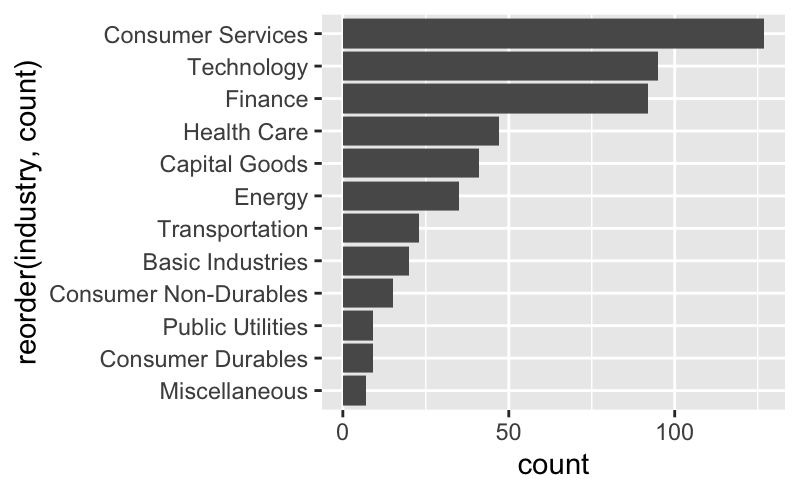

```r
#Create plot of total students in each sectorx
ggplot(sector_totals) +
  aes(x = reorder(industry, count), y = count) +
  geom_col() +
  coord_flip()
```

What is the gender split in these sectors?

```r
#Get overall gender split - remove 2 NAs and 1 prefer not to say
total_gender <-
students_companies %>%
  filter(!is.na(gender)) %>%
  filter(gender != "Prefer not to say") %>%
  group_by(gender) %>%
  summarise(count = n())
total_gender
```

| gender | count |
| --- | --- |
| Female | 187 |
| Male | 463 |

```r
#Find gender ratio in each sector - remove "Prefer not to say" as only one entry
sector_by_gender <-
students_companies %>%
  filter(!industry == "n/a") %>%
  filter(!is.na(gender)) %>%
  filter(gender != "Prefer not to say") %>%
  group_by(industry, gender) %>%
  summarise(count = n())
sector_by_gender
```

| industry | gender | count |
| --- | --- | --- |
| Basic Industries | Female | 4 |
| Basic Industries | Male | 16 |
| Capital Goods | Female | 16 |
| Capital Goods | Male | 25 |
| Consumer Durables | Female | 2 |
| Consumer Durables | Male | 7 |
| Consumer Non-Durables | Female | 3 |
| Consumer Non-Durables | Male | 12 |
| Consumer Services | Female | 31 |
| Consumer Services | Male | 95 |

[output cut: 14 more lines]

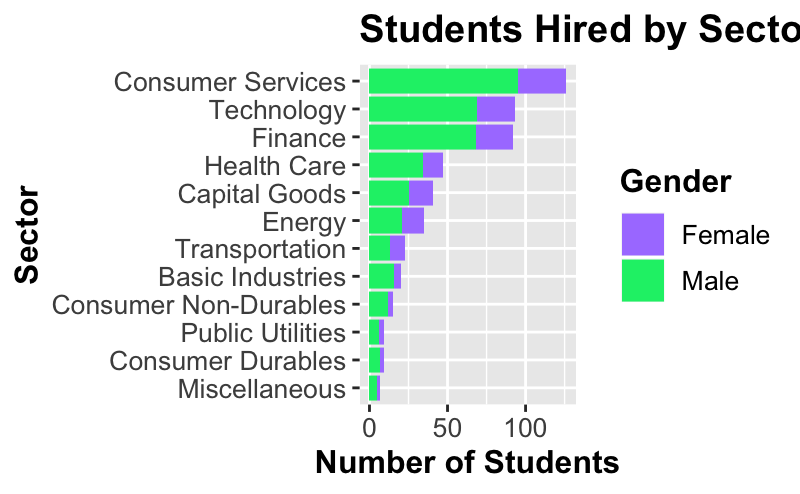

```r
#Create a plot splitting each sector by gender
ggplot(sector_by_gender) +
  aes(x = reorder(industry, count), y = count, fill = gender) +
  geom_col() +
  coord_flip() +
  labs(title = "Students Hired by Sector, with Gender Split", x = "Sector",
       y = "Number of Students") +
  scale_fill_manual(name = "Gender", values = c("mediumpurple1", "springgreen2")) +
  theme(title = element_text(size = 12, face = "bold"),
                  axis.title = element_text(size = 12, face = "bold"),
                  axis.text = element_text(size = 10),
                  legend.text = element_text(size = 10))
ggsave("industry_gender.jpg")
```

What is the average age in these sectors?

```r
#Replace 0 ages with mean age
students_companies$age <- ifelse(students_companies$age == 0, mean(students_companies$age), students_companies$age)
```

```r
#Get average age by sector - remove 15 entries with outlying ages (probably entered wrong)
sector_by_age <-
students_companies %>%
  filter(!industry == "n/a") %>%
  filter(age != 3:5) %>%
  group_by(industry) %>%
  summarise(mean_age = mean(age))
```

```
longer object length is not a multiple of shorter object length
```

```r
sector_by_age
```

| industry | mean_age |
| --- | --- |
| Basic Industries | 30.00000 |
| Capital Goods | 32.39559 |
| Consumer Durables | 29.11111 |
| Consumer Non-Durables | 33.89587 |
| Consumer Services | 32.21051 |
| Energy | 31.67647 |
| Finance | 31.92516 |
| Health Care | 36.21479 |
| Miscellaneous | 33.57143 |
| Public Utilities | 30.57989 |

[output cut: 2 more lines]

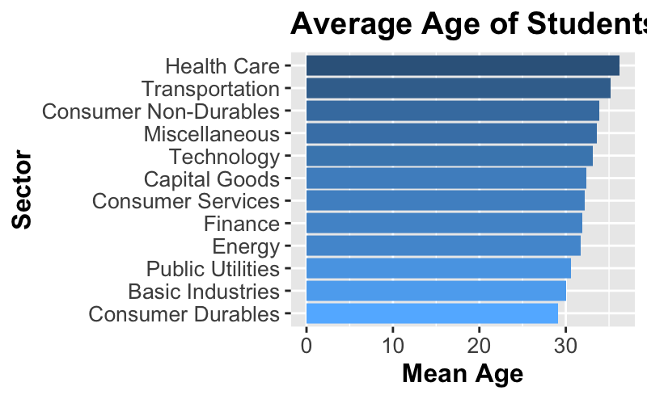

```r
#Plot mean age by sector
ggplot(sector_by_age) +
  aes(x = reorder(industry, mean_age), y = mean_age, fill = mean_age) +
  geom_col() +
  coord_flip() +
  labs(title = "Average Age of Students by Sector", x = "Sector",
       y = "Mean Age") +
  scale_fill_gradient(low = "steelblue1", high = "steelblue4") +
  theme(title = element_text(size = 12, face = "bold"),
                  axis.title = element_text(size = 12, face = "bold"),
                  axis.text = element_text(size = 10),
                  legend.position = "none")
ggsave("age_industry.jpg")
```

What are the top 5 most popular sectors?

```r
#Get top 5 and create wordcloud
sector_totals %>%
  top_n(5) %>%
  ggplot(aes(label = industry, size = count, colour = industry)) +
  geom_text_wordcloud() +
  scale_color_brewer(palette = 2) +
  theme(panel.background = element_rect(fill = "white"))
ggsave("top_wordcloud.jpg")
```

[output not shown]

What are the bottom 5 sectors?

```r
#Get botton 5 and create wordcloud?
sector_totals %>%
  tail(5) %>%
  ggplot(aes(label = industry, size = count, colour = industry)) +
  geom_text_wordcloud() +
  scale_color_brewer(palette = 3) +
  theme(panel.background = element_rect(fill = "white"))
ggsave("bottom_wordcloud.jpg")
```

[output not shown]

Who are the top 10 best business recruiting?

```r
#Get top ten companies - remove 23 NAs as small proportion of total. Then find out
#which industries these companies are in.
top_ten_companies <-
students_companies %>%
  filter(!is.na(company_ID)) %>%
  group_by(company_ID) %>%
  summarise(count = n()) %>%
  arrange(desc(count)) %>%
  top_n(10)
top_ten_companies
```

| company_ID | count |
| --- | --- |
| company_695 | 32 |
| company_66 | 28 |
| company_19 | 21 |
| company_39 | 21 |
| company_427 | 21 |
| company_486 | 18 |
| company_57 | 15 |
| company_74 | 14 |
| company_55 | 11 |
| company_101 | 8 |

[output cut: 1 more lines]

```r
top_ten_industry <-
students_companies %>%
  select(company_ID, industry) %>%
  filter(company_ID %in% top_ten_companies$company_ID) %>%
  group_by(company_ID, industry) %>%
  summarise(count = n()) %>%
  arrange(desc(count))
top_ten_industry
```

| company_ID | industry | count |
| --- | --- | --- |
| company_695 | Consumer Services | 32 |
| company_66 | Consumer Services | 28 |
| company_19 | Consumer Services | 21 |
| company_39 | Technology | 21 |
| company_427 | Technology | 21 |
| company_486 | Technology | 18 |
| company_57 | Finance | 15 |
| company_74 | Energy | 14 |
| company_55 | Transportation | 11 |
| company_101 | n/a | 8 |

[output cut: 1 more lines]

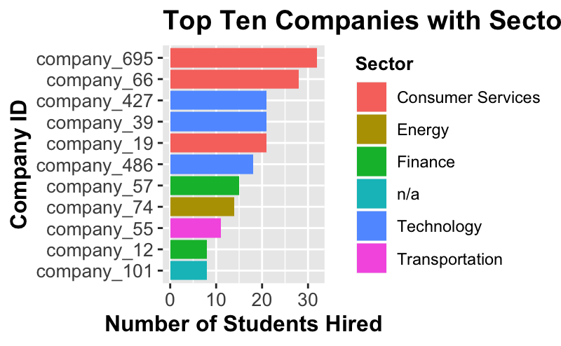

```r
#Plot top ten companies with industries
ggplot(top_ten_industry) +
  aes(x = reorder(company_ID, count), y = count, fill = industry) +
  geom_col() +
  coord_flip() +
  scale_fill_discrete(name = "Sector") +
  labs(title = "Top Ten Companies with Sectors", x = "Company ID",
       y = "Number of Students Hired") +
  theme(title = element_text(size = 12, face = "bold"),
                  axis.title = element_text(size = 12, face = "bold"),
                  axis.text = element_text(size = 10),
                  legend.title = element_text(size = 10))
ggsave("top_ten.jpg")
```

What are the trends for each year a student graduated vs business area placed?

```r
#Get years from date_became_partner variable - 195 NAs - remove as no other option
students_companies$year <- format(as.Date(students_companies$course_start_date, format="%d/%m/%Y"),"%Y")
```

```r
#Students who start the course after September will graduate in the next year - change
#year to reflect this
students_companies$month <-
format(as.Date(students_companies$course_start_date, format="%d/%m/%Y"), "%m")

students_companies <-
students_companies %>%
  mutate(year = case_when(
    month %in% 9:12 & year == 2015 ~ 2016,
    month %in% 9:12 & year == 2016 ~ 2017,
    month %in% 9:12 & year == 2017 ~ 2018,
    month %in% 9:12 & year == 2018 ~ 2019,
    TRUE ~ as.numeric(year)
  ))
```

```r
#Find hiring trend over time
trends_sector <-
students_companies %>%
  filter(!is.na(year)) %>%
  filter(!industry == "n/a") %>%
  group_by(industry, year) %>%
  summarise(count = n())
trends_sector
```

| industry | year | count |
| --- | --- | --- |
| Basic Industries | 2016 | 1 |
| Basic Industries | 2017 | 8 |
| Basic Industries | 2018 | 5 |
| Basic Industries | 2019 | 6 |
| Capital Goods | 2016 | 8 |
| Capital Goods | 2017 | 9 |
| Capital Goods | 2018 | 15 |
| Capital Goods | 2019 | 9 |
| Consumer Durables | 2016 | 3 |
| Consumer Durables | 2017 | 1 |

[output cut: 38 more lines]

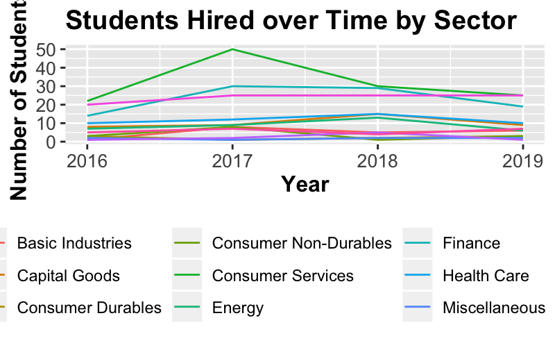

```r
#Plot trends over time
ggplot(trends_sector) +
  aes(x = year, y = count, group = industry, colour = industry) +
  geom_line() +
  scale_colour_discrete(name = "Sector") +
  labs(title = "Students Hired over Time by Sector", x = "Year",
       y = "Number of Students") +
  theme(title = element_text(size = 12, face = "bold"),
                  axis.title = element_text(size = 12, face = "bold"),
                  axis.text = element_text(size = 10),
                  legend.title = element_text(size = 10),
        legend.position = "bottom")
ggsave("hiring_trends.jpg")
```

New question - which companies aren’t recruiting?

```r
#Find companies that aren't in the students dataset
setwd('/Users/user/Desktop/ga_project')
```

```
The working directory was changed to /Users/user/Desktop/ga_project inside a notebook chunk. The working directory will be reset when the chunk is finished running. Use the knitr root.dir option in the setup chunk to change the working directory for notebook chunks.
```

```r
companies <- read_csv("./inputs/companies_synth.csv")
students <- read_csv("./inputs/students_synth.csv")
non_hiring_companies <- companies %>% anti_join(students, by = "company_ID")
```

```r
non_hiring_companies$year <- format(as.Date(non_hiring_companies$date_became_partner, format="%d/%m/%Y"),"%Y")
```

```r
#See who isn't hiring each year
non_hiring_companies %>%
  filter(!industry == "n/a") %>%
  filter(!is.na(year)) %>%
  group_by(industry, year) %>%
  summarise(count = n()) %>%
  arrange(desc(count))
```

| industry | year | count |
| --- | --- | --- |
| Finance | 2016 | 31 |
| Finance | 2018 | 30 |
| Finance | 2017 | 22 |
| Finance | 2019 | 22 |
| Health Care | 2016 | 18 |
| Technology | 2017 | 18 |
| Consumer Services | 2019 | 17 |
| Health Care | 2018 | 17 |
| Technology | 2016 | 17 |
| Consumer Services | 2018 | 16 |

[output cut: 37 more lines]

```r
#Find non-hiring companies sizes and sectors
non_hiring_size <-
non_hiring_companies %>%
  filter(!industry == "n/a") %>%
  filter(!is.na(`Company Size`)) %>%
  group_by(industry, `Company Size`) %>%
  summarise(count = n()) %>%
  arrange(desc(count))
non_hiring_size
```

| industry | Company Size | count |
| --- | --- | --- |
| Health Care | Micro (0-14) | 18 |
| Finance | Micro (0-14) | 17 |
| Finance | Large (250+) | 16 |
| Consumer Services | Micro (0-14) | 12 |
| Technology | Micro (0-14) | 11 |
| Finance | Small (15-49) | 9 |
| Capital Goods | Micro (0-14) | 8 |
| Technology | Large (250+) | 8 |
| Consumer Services | Small (15-49) | 7 |
| Consumer Non-Durables | Micro (0-14) | 6 |

[output cut: 32 more lines]

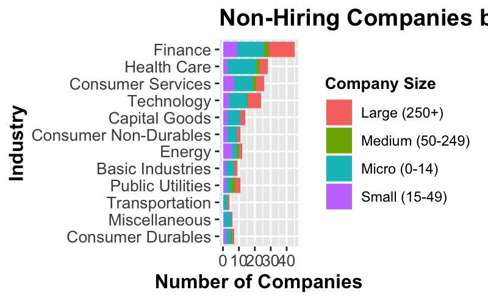

```r
#Plot non-hiring companies
ggplot(non_hiring_size) +
  aes(x = reorder(industry, count), y = count, fill = `Company Size`) +
  geom_col() +
  coord_flip() +
  scale_fill_discrete(name = "Company Size") +
  labs(title = "Non-Hiring Companies by Sector and Size", x = "Industry",
       y = "Number of Companies") +
  theme(title = element_text(size = 12, face = "bold"),
                  axis.title = element_text(size = 12, face = "bold"),
                  axis.text = element_text(size = 10),
                  legend.title = element_text(size = 10))
ggsave("non_hiring_size.jpg")
```

```r
#Find proportions of non-hiring companies in each sector compared to overall
#proportion in dataset
non_hiring_industry <-
non_hiring_companies %>%
  filter(!industry == "n/a") %>%
  group_by(industry) %>%
  summarise(count = n()) %>%
  arrange(desc(count))
non_hiring_industry
```

| industry | count |
| --- | --- |
| Finance | 105 |
| Health Care | 66 |
| Consumer Services | 60 |
| Technology | 57 |
| Basic Industries | 36 |
| Capital Goods | 31 |
| Energy | 24 |
| Consumer Non-Durables | 23 |
| Public Utilities | 23 |
| Transportation | 13 |

[output cut: 2 more lines]

```r
company_by_industry <-
companies %>%
  filter(!industry == "n/a") %>%
  group_by(industry) %>%
  summarise(count = n()) %>%
  arrange(desc(count))
company_by_industry
```

| industry | count |
| --- | --- |
| Finance | 143 |
| Health Care | 93 |
| Consumer Services | 87 |
| Technology | 77 |
| Capital Goods | 52 |
| Basic Industries | 47 |
| Energy | 35 |
| Consumer Non-Durables | 33 |
| Public Utilities | 30 |
| Miscellaneous | 17 |

[output cut: 2 more lines]

[figure not shown]

```r
ggplot() +
  geom_col(data = company_by_industry, mapping = aes(x = reorder(industry, count),
                                                     y = count, fill = "plum3")) +
    geom_col(data = non_hiring_industry, mapping = aes(x = reorder(industry, count),
                                                       y = count, fill = "olivedrab3")) +
  coord_flip() +
  scale_fill_manual(labels = c("Hiring", "Non-Hiring"), values = c("plum3", "olivedrab3"),
                    name = "Status") +
  labs(title = "Proportion of Companies Hiring", x = "Industry",
       y = "Number of Companies") +
  theme(title = element_text(size = 12, face = "bold"),
                  axis.title = element_text(size = 12, face = "bold"),
                  axis.text = element_text(size = 10),
                  legend.title = element_text(size = 10))
ggsave("non_hiring_prop.jpg")
```

Company size?

```r
#Break down students hired by size of company
company_by_size <-
students_companies %>%
  filter(!is.na(company_size)) %>%
  group_by(company_size) %>%
  summarise(count = n())
company_by_size
```

| company_size | count |
| --- | --- |
| Large (250+) | 215 |
| Medium (50-249) | 86 |
| Micro (0-14) | 123 |
| Small (15-49) | 79 |

Company location?

```r
#Find location of hiring companies
unique(students_companies$company_location)
```

```
  [1] NA                       "Ankou"                  "Munka-Ljungby"
  [4] "El Banco"               "Guantian"               "El Guapinol"
  [7] "Milán"                  "Béja"                   "Anping"
 [10] "Itinga"                 "Pedro Santana"          "Dodoma"
 [13] "Asamankese"             "Chichibu"               "Suzano"
 [16] "Sliema"                 "San Juan Opico"         "Kagal’nitskaya"
 [19] "Swedru"                 "Alilem"                 "Guanting"
 [22] "Carcassonne"            "Erfangping"             "Qiantang"
 [25] "Ibitinga"               "Foumbouni"              "Greater Napanee"
 [28] "Galán"                  "Chantilly"              "Girón"
 [31] "Karara"                 "Dul’durga"              "Gondang"
 [34] "Talas"                  "Caijiazha"              "Paris 13"
 [37] "Nové Město nad Metují"  "Mananjary"              "Malanay"
 [40] "Sevilla"                "Gjegjan"                "Tajao"
 [43] "Xiawuqi"                "Balangkayan"            "Syktyvkar"
```

[output cut: 66 more lines]

```r
students_companies %>%
  filter(!is.na(company_location)) %>%
  group_by(company_location) %>%
  summarise(count = n()) %>%
  arrange(desc(count))
```

| company_location | count |
| --- | --- |
| Strážnice | 28 |
| Ayia Napa | 21 |
| Paseka | 21 |
| Rukem | 21 |
| Ajaccio | 18 |
| Síkinos | 16 |
| Trinidad | 16 |
| Cabiguan | 15 |
| Yako | 14 |
| Dehui | 11 |

[output cut: 231 more lines]

Partners vs non-partners?

```r
#Decide on which partner variable to use - choose parter status as easiest to visualise
unique(students_companies$partner_status)
```

```
[1] "Non Partner"    "Hiring Partner"
```

```r
unique(students_companies$company_status)
```

```
[1] NA            "Partner"     "Non Partner"
```

```r
unique(students_companies$partner_segmentation)
```

```
[1] NA                           "Hiring Partner"
[3] "Client Experience"          "Hiring & Training"
[5] "Channel Partner / Advocate" "Influencer"
[7] "Training Partner"
```

```r
#Find partner status breakdown
partner_status_breakdown <-
students_companies %>%
  group_by(partner_status) %>%
  summarise(count = n())
partner_status_breakdown
```

| partner_status | count |
| --- | --- |
| Hiring Partner | 434 |
| Non Partner | 219 |

```r
#Check to see if partner segmentation any more interesting
students_companies %>%
  filter(!is.na(partner_segmentation)) %>%
  group_by(partner_segmentation) %>%
  summarise(count = n())
```

| partner_segmentation | count |
| --- | --- |
| Channel Partner / Advocate | 1 |
| Client Experience | 1 |
| Hiring & Training | 67 |
| Hiring Partner | 405 |
| Influencer | 2 |
| Training Partner | 2 |

Job title?

```r
#Look at job titles - not really anything interesting to plot
students_companies %>%
  filter(!is.na(job_title)) %>%
  filter(job_title != "Unknown") %>%
  group_by(job_title, industry) %>%
  summarise(count = n()) %>%
  arrange(desc(count))
```

| job_title | industry | count |
| --- | --- | --- |
| Actuary | n/a | 4 |
| Chemical Engineer | Consumer Services | 4 |
| Information Systems Manager | Consumer Services | 4 |
| Payment Adjustment Coordinator | Finance | 4 |
| Quality Control Specialist | n/a | 4 |
| Sales Representative | Consumer Services | 4 |
| Social Worker | Finance | 4 |
| Administrative Officer | Technology | 3 |
| Assistant Manager | Health Care | 3 |
| Automation Specialist IV | Consumer Services | 3 |

[output cut: 480 more lines]